# ATML Project Report

#### Dusan Mihajlov, Pinar Goktepe, Michael Baur

## Clothing Classification with Self Supervised Learning

Project Goal: Our goal is to employ self supervised learning methodology to provide better classification performance with less number of labeled data. For both pretext task and target task, the dataset named Deep Fashion (http://mmlab.ie.cuhk.edu.hk/projects/DeepFashion.html) is used. This dataset contains 289,222 images with 48 categories. As pretext task, a square jigsaw puzzle is solved and target task is classification of 48 different types of clothes.

## Dataset

DeepFashion dataset is divided into two subdatasets with an initial ratio of 70%-30%. This means that 70% of all instances in a class selected for first dataset and 30% of the instances in the same class separated for the second dataset. The larger dataset is used while solving the pretext task and target task which is classification is completed on smaller dataset. This difference in dataset sizes occured becuse the pretext task will be solved without actual labels. For pretext task, the instances in larger dataset divided into tiles whose size is selected based on experimental results. After tiles are constructed, they are shuffled. As pretext task, the network is asked to order the tiles of given image correctly.

## Approach Description

The main idea of the self supervised learning is to solve tasks that do not require labeled images as input for feature learning. After solving those tasks which are called pretext tasks, the extracted features are used by the model that aims to solve target task on labeled data. In our project pretext task is Jigsaw puzzle solving and target task is classification. Since the network weights are transferred between two models, they should share the same architecture. After winning ImageNet LSVRC-2012, Alexnet took an important position in classification of images. It is deep enough to extract relavant features for classification tasks meanwhile requires less computational power when it is compared the VGG network family and other deeper architectures. Therefore we decided to use Alexnet for our classification task as well as the pretext task.

In order to analyse the performance of selfsupervised learning appraoch, we run experiments for classification on alexnet with random initialization and alexnet with ImageNet pretraining. To be able to use the pretrained model, we modified the last layer of pretrained network by the number of classes which is 48.

Dataset splitting is completed in dataset.py, data preprocessing for pretext task is in Datasets.py, training pipeline for pretext task is in self_train.py, training pipeline for target task is in class_train.py and testing pipeline for target task is in testing_classification.py. The required functions for training and testing can be found in functions.py.

We used top-1, top-3 and top-5 accuracies as evaluation metrics.

## Results

#### Parameters for classification:

lr = 0.0001, epcohs = 20, optimizer = Adam, weight decay = 0.001, scheduler = StepLR, step size = 5, gamma = 0.3, batch size = 64

#### Parameters for jigsaw puzzle solving:

lr = 0.0005, epcohs = 20, optimizer = Adam, weight decay = 0.001, scheduler = StepLR, step size = 5, gamma = 0.3, batch size = 64, tile size = 75 or 113 (75 for 3x3 puzzle, 113 for 2x2 puzzle)

Validation Accuracies for Classification without Pretraining and Pretext Task Solving:

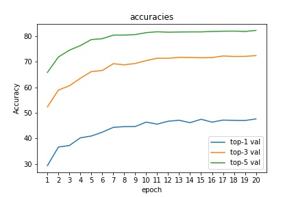

### Learning Curves

Training and Validation Losses for Classification without Pretraining and Pretext Task Solving:

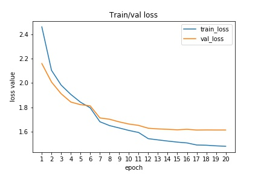

Training and Validation Losses for Classification with Pretext Task Solving:

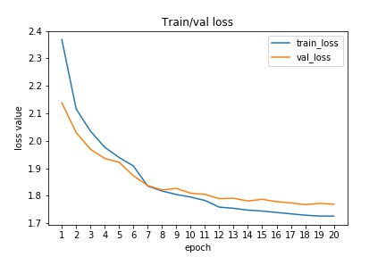

Training and Validation Losses for Classification with Pretraining:

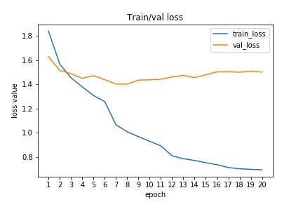

### Test Performance

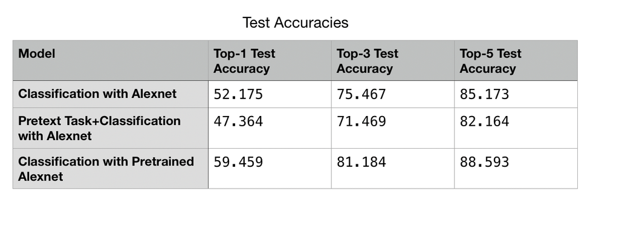

### Discussion

As learning curves and test accuracies demonstrated, Alexnet with pretraining outperformed the rest. The reason for this might be the wide range of images in the ImageNet causing more generalization power for the network. ImageNet is a massive collection of images although deepfashion is a modarate size dataset. The other drawback of pretext task is its main focus during training. During the ImageNet pretraining, the task that network focuses on is classification same as the target task. However, pretext task focuses more on spatial information of patches because of its formulation. These factors may lead pretrained network to outperform for our problem. Although self supervised learning provides supervision when the labeled data is limited, supervised learning still preforms better for our problem and dataset. A possible reason might be the following. Since the pretext task focuses on the spatial locations of different parts of the image, this may cause learning features which are not valueable for classification. We can conclude that even the performances of classification with alexnet and classification after the pretext task with alexnet are close to each other, self supervised learning approach does not suited well for classification task particularly on DeepFashion dataset. Another problem is that solving pretext task reqiures longer training procedure since it has to be trained with large amount of images while classification can be done with much smaller dataset. Therefore parameter optimization becomes an issue for self supervised approaches. Since both pretext solver network and the classification network need optimized parameters to provide better performances, at least two times of the number of parameters in classification (there can be additional parameters such as tile size) need to be optimized. This might be another reason for not getting better performance with selfsupervised learning. If time and computational power allow, one can improve performance of self supervised learning approach for our target task on DeepFashion dataset. Even it may surpass the performance of supervised classification without pretraining and pretext task because the gap between those two different approach is around 4%. Lastly, deeper architectures such as vgg19 may extract better features however we are not able conduct experiments with it since its training takes significant amount of time. Although we could not try another architecture, we added 2 linear layers and 2dropout layers to alexnet architecture but we cannot gain any improvement on either pretext task solver network and classification network.

Note: We cannot provide prediction with current network directly in this notebook since our model is 426mb and our dataset is more than 2gb. So, putting them to github is impossible since it has 100mb size restriction per files and it does not allow repositories to have a size more than 1gb.